# Basic tools for time-to-event trial simulation and testing

Keaven Anderson

## Overview

This vignette demonstrates the lower-level routines in the simtrial package specifically related to trial generation and statistical testing.

The routines are as follows:

- `randomize_by_fixed_block()` - fixed block randomization
- `rpwexp_enroll()` - random inter-arrival times with piecewise constant enrollment rates
- `rpwexp()` - piecewise exponential failure rate generation
- `cut_data_by_date()` - cut data for analysis at a specified calendar time
- `cut_data_by_event()` - cut data for analysis at a specified event count, including ties on the cutoff date
- `get_cut_date_by_event()` - find date at which an event count is reached
- `counting_process()` - pre-process survival data into a counting process format

Application of the above is demonstrated using higher-level routines `sim_pw_surv()` and `sim_fixed_n()` to generate simulations and weighted logrank analysis for a stratified design.

The intent has been to write these routines in the spirit of the tidyverse approach (alternately referred to as data wrangling, tidy data, R for Data Science, or split-apply-combine). The other objectives are to have an easily documentable and validated package that is easy to use and efficient as a broadly-useful tool for simulation of time-to-event clinical trials.

The package could be extended in many ways in the future, including:

- Other analyses not supported in the survival package or other acceptably validated package
  - Weighted logrank and weighted Kaplan-Meier analyses
  - One-step, hazard ratio estimator (first-order approximation of PH)
- Randomization schemes other than stratified, fixed-block
- Poisson mixture or other survival distribution generation

```r
library(simtrial)
library(gt)
library(dplyr)
```

## Randomization

```r
randomize_by_fixed_block(n = 10, block = c("A", "Dog", "Cat", "Cat"))
```

```
#>  [1] "A"   "Cat" "Cat" "Dog" "Cat" "Dog" "Cat" "A"   "Dog" "Cat"
```

More normally, with a default of blocks of size four:

```r
randomize_by_fixed_block(n = 20)
```

```
#>  [1] 1 0 1 0 1 1 0 0 0 1 0 1 0 1 0 1 0 1 1 0
```

## Enrollment

Piecewise constant enrollment can be randomly generated as follows. Note that duration is specifies interval durations for constant rates; the final rate is extended as long as needed to generate the specified number of observations.

```r
rpwexp_enroll(
  n = 20,
  enroll_rate = data.frame(
    duration = c(1, 2),
    rate = c(2, 5)
  )
)
```

```
#>  [1] 0.6470602 0.7829328 0.8209463 1.0466624 1.9544601 2.0594392 2.1060726
#>  [8] 2.4646275 2.5787125 3.0770926 3.2764552 3.5635123 3.5709660 3.6357680
#> [15] 3.8998616 3.9405637 4.1451088 4.2054570 4.3504999 4.5008084
```

## Time-to-event and time-to-dropout

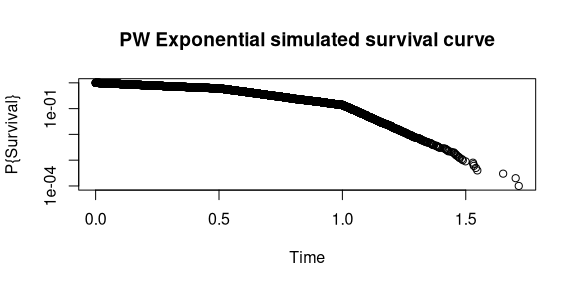

```r
x <- rpwexp(
  10000,
  fail_rate = data.frame(
    rate = c(1, 3, 10),
    duration = c(.5, .5, 1)
  )
)
plot(
  sort(x),
  (10000:1) / 10001,
  log = "y",
  main = "PW Exponential simulated survival curve",
  xlab = "Time", ylab = "P{Survival}"
)
```

## Generating a trial

Ideally, this might be done with a routine where generation of randomization, and time-to-event data could be done in a modular fashion plugged into a general trial generation routine. For now, stratified randomization, piecewise constant enrollment, fixed block randomization and piecewise exponential failure rates support a flexible set of trial generation options for time-to-event endpoint trials. At present, follow this format very carefully as little checking of input has been developed to-date. The methods used here have all be demonstrated above, but here they are combined in a single routine to generate a trial. Note that in the generated output dataset, `cte` is the calendar time of an event or dropout, whichever comes first, and `fail` is an indicator that `cte` represents an event time.

First we set up input variables to make the later call to `sim_pw_surv()` more straightforward to read.

```r
stratum <- data.frame(stratum = c("Negative", "Positive"), p = c(.5, .5))

block <- c(rep("control", 2), rep("experimental", 2))

enroll_rate <- data.frame(rate = c(3, 6, 9), duration = c(3, 2, 1))

fail_rate <- data.frame(
  stratum = c(rep("Negative", 4), rep("Positive", 4)),
  period = rep(1:2, 4),
  treatment = rep(c(rep("control", 2), rep("experimental", 2)), 2),
  duration = rep(c(3, 1), 4),
  rate = log(2) / c(4, 9, 4.5, 10, 4, 9, 8, 18)
)
dropout_rate <- data.frame(
  stratum = c(rep("Negative", 4), rep("Positive", 4)),
  period = rep(1:2, 4),
  treatment = rep(c(rep("control", 2), rep("experimental", 2)), 2),
  duration = rep(c(3, 1), 4),
  rate = rep(c(.001, .001), 4)
)
```

```r
x <- sim_pw_surv(
  n = 400,
  stratum = stratum,
  block = block,
  enroll_rate = enroll_rate,
  fail_rate = fail_rate,
  dropout_rate = dropout_rate
)

head(x) |>
  gt() |>
  fmt_number(columns = c("enroll_time", "fail_time", "dropout_time", "cte"), decimals = 2)
```

| stratum | enroll_time | treatment | fail_time | dropout_time | cte | fail |
| --- | --- | --- | --- | --- | --- | --- |
| Positive | 0.72 | experimental | 7.41 | 238.65 | 8.13 | 1 |
| Positive | 1.03 | control | 1.28 | 471.62 | 2.32 | 1 |
| Positive | 1.58 | experimental | 4.58 | 923.42 | 6.16 | 1 |
| Negative | 2.22 | control | 47.96 | 505.07 | 50.19 | 1 |
| Negative | 2.41 | experimental | 26.38 | 87.34 | 28.79 | 1 |
| Negative | 2.60 | control | 2.86 | 516.07 | 5.45 | 1 |

## Cutting data for analysis

There two ways to cut off data in the generated dataset `x` from above. The first uses a calendar cutoff date. The output only includes the time from randomization to event or dropout (`tte`), and indicator that this represents and event (`event`), the stratum in which the observation was generated (`stratum`) and the treatment group assigned (`treatment`). Observations enrolled after the input `cut_date` are deleted and events and censoring from `x` that are after the `cut_date` are censored at the specified `cut_date`.

```r
y <- cut_data_by_date(x, cut_date = 5)

head(y) |>
  gt() |>
  fmt_number(columns = "tte", decimals = 2)
```

| tte | event | stratum | treatment |
| --- | --- | --- | --- |
| 4.28 | 0 | Positive | experimental |
| 1.28 | 1 | Positive | control |
| 3.42 | 0 | Positive | experimental |
| 2.78 | 0 | Negative | control |
| 2.59 | 0 | Negative | experimental |
| 2.40 | 0 | Negative | control |

For instance, if we wish to cut the entire dataset when 50 events are observed in the Positive stratum we can use the `get_cut_date_by_event` function as follows:

```r
cut50Positive <- get_cut_date_by_event(filter(x, stratum == "Positive"), 50)
y50Positive <- cut_data_by_date(x, cut50Positive)

with(y50Positive, table(stratum, event))
```

```
#>           event
#> stratum     0  1
#>   Negative 44 57
#>   Positive 46 50
```

Perhaps the most common way to cut data is with an event count for the overall population, which is done using the `cut_data_by_event` function. Note that if there are tied events at the date the `cte` the count is reached, all are included. Also, if the count is never reached, all event times are included in the cut - with no indication of an error.

```r
y150 <- cut_data_by_event(x, 150)
table(y150$event, y150$treatment)
```

```
#>
#>     control experimental
#>   0      56           56
#>   1      76           74
```

## Generating a counting process dataset

Once we have cut data for analysis, we can create a dataset that is very simple to use for weighted logrank tests. A slightly more complex version could be developed in the future to enable Kaplan-Meier-based tests. We take the dataset `y150` from above and process it into this format. The counting process format is further discussed in the next section where we compute a weighted logrank test.

```r
ten150 <- counting_process(y150, arm = "experimental")

head(ten150) |>
  gt() |>
  fmt_number(columns = c("tte", "o_minus_e", "var_o_minus_e"), decimals = 2)
```

| stratum | event_total | event_trt | tte | n_risk_total | n_risk_trt | s | o_minus_e | var_o_minus_e |
| --- | --- | --- | --- | --- | --- | --- | --- | --- |
| Negative | 1 | 0 | 0.05 | 132 | 66 | 1.0000000 | −0.50 | 0.25 |
| Negative | 1 | 1 | 0.06 | 131 | 66 | 0.9924242 | 0.50 | 0.25 |
| Negative | 1 | 1 | 0.10 | 130 | 65 | 0.9848485 | 0.50 | 0.25 |
| Negative | 1 | 1 | 0.11 | 129 | 64 | 0.9772727 | 0.50 | 0.25 |
| Negative | 1 | 0 | 0.18 | 126 | 62 | 0.9696970 | −0.49 | 0.25 |
| Negative | 1 | 1 | 0.28 | 125 | 62 | 0.9620010 | 0.50 | 0.25 |

## Logrank and weighted logrank testing

Now stratified logrank and stratified weighted logrank tests are easily generated based on the counting process format. Each record in the counting process dataset represents a `tte` at which one or more events occurs; the results are stratum-specific. Included in the observation is the number of such events overall (`events`) and in the experimental treatment group (`txevents`), the number at risk overall (`atrisk`) and in the experimental treatment group (`txatrisk`) just before `tte`, the combined treatment group Kaplan-Meier survival estimate (left-continuous) at `tte`, the observed events in experimental group minus the expected at `tte` based on an assumption that all at risk observations are equally likely to have an event at any time, and the variance for this quantity (`Var`).

To generate a stratified logrank test and a corresponding one-sided p-value, we simply do the following:

```r
z <- with(ten150, sum(o_minus_e) / sqrt(sum(var_o_minus_e)))
c(z, pnorm(z))
```

```
#> [1] -0.2895112  0.3860951
```

A Fleming-Harrington $\rho=1$, $\gamma=2$ is nearly as simple. We again compute a z-statistic and its corresponding one-sided p-value.

```r
xx <- mutate(ten150, w = s * (1 - s)^2)
z <- with(xx, sum(o_minus_e * w) / sum(sqrt(var_o_minus_e * w^2)))
c(z, pnorm(z))
```

```
#> [1] -0.05117009  0.47959499
```

For Fleming-Harrington tests, a routine has been built to do these tests for you:

```r
fh00 <- y150 |> wlr(weight = fh(rho = 0, gamma = 0))
fh01 <- y150 |> wlr(weight = fh(rho = 0, gamma = 1))
fh10 <- y150 |> wlr(weight = fh(rho = 1, gamma = 0))
fh11 <- y150 |> wlr(weight = fh(rho = 1, gamma = 1))

temp_tbl <- fh00 |>
  unlist() |>
  as.data.frame() |>
  cbind(fh01 |> unlist() |> as.data.frame()) |>
  cbind(fh10 |> unlist() |> as.data.frame()) |>
  cbind(fh11 |> unlist() |> as.data.frame())

colnames(temp_tbl) <- c("Test 1", "Test 2", "Test 3", "Test 4")
temp_tbl
```

```
#>                       Test 1             Test 2             Test 3
#> method                   WLR                WLR                WLR
#> parameter FH(rho=0, gamma=0) FH(rho=0, gamma=1) FH(rho=1, gamma=0)
#> estimate   -1.75426724971014 -0.818939721517279 -0.935327528192858
#> se          6.05941000553282   2.27052267790595   4.34589611551245
#> z          0.289511230979307  0.360683348149848  0.215220866613506
#> info        37.4933333333333   5.43877027758393   19.0509083739413
#> info0                   37.5   5.43986915996561   19.0517536229051
#>                       Test 4
#> method                   WLR
#> parameter FH(rho=1, gamma=1)
#> estimate  -0.533798430409904
#> se          1.13850132889467
#> z          0.468860612510791
#> info        1.33161103534454
#> info0       1.33288216436227
```

```r
y150 |>
  maxcombo(rho = c(0, 0, 1, 1), gamma = c(0, 1, 0, 1))
```

```
#> $method
#> [1] "MaxCombo"
#>
#> $parameter
#> [1] "FH(0, 0) + FH(0, 1) + FH(1, 0) + FH(1, 1)"
#>
#> $z
#> [1] -0.2895112 -0.3606833 -0.2152209 -0.4688606
#>
#> $p_value
#> [1] 0.4554353
```

## Simplification for 2-arm trials

The `sim_fixed_n()` routine combines much of the above to go straight to generating tests for individual trials so that cutting data and analyzing do not need to be done separately. Here the argument structure is meant to be simpler than for `sim_pw_surv()`.

```r
stratum <- data.frame(stratum = "All", p = 1)
enroll_rate <- data.frame(
  duration = c(2, 2, 10),
  rate = c(3, 6, 9)
)
fail_rate <- data.frame(
  stratum = "All",
  duration = c(3, 100),
  fail_rate = log(2) / c(9, 18),
  hr = c(0.9, 0.6),
  dropout_rate = rep(0.001, 2)
)
block <- rep(c("experimental", "control"), 2)
rho_gamma <- data.frame(rho = 0, gamma = 0)
```

Now we simulate a trial 2 times and cut data for analysis based on `timing_type = 1:5` which translates to:

1. the planned study duration,
2. targeted event count is achieved,
3. planned minimum follow-up after enrollment is complete,
4. the maximum of 1 and 2,
5. the maximum of 2 and 3.

```r
sim_fixed_n(
  n_sim = 2, # Number of simulations
  sample_size = 500, # Trial sample size
  target_event = 350, # Targeted events at analysis
  stratum = stratum, # Study stratum
  enroll_rate = enroll_rate, # Enrollment rates
  fail_rate = fail_rate, # Failure rates
  total_duration = 30, # Planned trial duration
  block = block, # Block for treatment
  timing_type = 1:5, # Use all possible data cutoff methods
  rho_gamma = rho_gamma # FH test(s) to use; in this case, logrank
) |>
  gt() |>
  fmt_number(columns = c("ln_hr", "z", "duration"))
```

```
#> Backend uses sequential processing.
```

| method | parameter | estimate | se | z | event | ln_hr | cut | duration | sim |
| --- | --- | --- | --- | --- | --- | --- | --- | --- | --- |
| WLR | FH(rho=0, gamma=0) | -2.39249 | 4.580844 | 0.52 | 84 | −0.11 | Planned duration | 30.00 | 1 |
| WLR | FH(rho=0, gamma=0) | -28.06518 | 9.290784 | 3.02 | 350 | −0.32 | Targeted events | 70.68 | 1 |
| WLR | FH(rho=0, gamma=0) | -28.04463 | 9.290998 | 3.02 | 350 | −0.32 | Minimum follow-up | 70.71 | 1 |
| WLR | FH(rho=0, gamma=0) | -28.06518 | 9.290784 | 3.02 | 350 | −0.32 | Max(planned duration, event cut) | 70.68 | 1 |
| WLR | FH(rho=0, gamma=0) | -28.04463 | 9.290998 | 3.02 | 350 | −0.32 | Max(min follow-up, event cut) | 70.71 | 1 |
| WLR | FH(rho=0, gamma=0) | -16.25038 | 4.553044 | 3.57 | 84 | −0.80 | Planned duration | 30.00 | 2 |
| WLR | FH(rho=0, gamma=0) | -39.49521 | 9.193080 | 4.30 | 350 | −0.46 | Targeted events | 72.60 | 2 |
| WLR | FH(rho=0, gamma=0) | -38.90090 | 9.278315 | 4.19 | 357 | −0.45 | Minimum follow-up | 75.55 | 2 |
| WLR | FH(rho=0, gamma=0) | -39.49521 | 9.193080 | 4.30 | 350 | −0.46 | Max(planned duration, event cut) | 72.60 | 2 |
| WLR | FH(rho=0, gamma=0) | -38.90090 | 9.278315 | 4.19 | 357 | −0.45 | Max(min follow-up, event cut) | 75.55 | 2 |

If you look carefully, you should be asking why the cutoff with the planned number of events is so different than the other data cutoff methods. To explain, we note that generally you will want `sample_size` above to match the enrollment specified in `enroll_rate`:

```r
enroll_rate |> summarize(
  "Targeted enrollment based on input enrollment rates" = sum(duration * rate)
)
```

```
#>   Targeted enrollment based on input enrollment rates
#> 1                                                 108
```

```r
total_duration <- 30 # From above
total_duration - sum(enroll_rate$duration)
```

```
#> [1] 16
```

It is thus, implicit that the last subject was enrolled 16 months prior to the duration given for the cutoff with “Minimum follow-up” cutoff in the simulations above. The planned duration cutoff is given in the `total_duration` argument which results in a much earlier cutoff.